# Relações Tensão-Corrente em CA

Circuitos Elétricos II — CA

Prof. Dr. Raphael Teixeira

Universidade Federal do Pará

## Impedância: A Grande Ideia

No domínio fasorial, a relação tensão-corrente para **qualquer** elemento linear é:

$$\mathbf{V} = \mathbf{Z}\,\mathbf{I}$$

onde $\mathbf{Z}$ é a **impedância** — generalização da resistência para CA.

**Analogia com a Lei de Ohm**

A impedância $\mathbf{Z}$ faz para circuitos CA o que a resistência $R$ faz para CC. As mesmas técnicas de análise (divisor de tensão, nós, malhas, Thévenin…) se aplicam, mas com **números complexos**.

**Forma geral:**

$$\mathbf{Z} = R + jX \qquad [\Omega]$$

- $R$ — resistência (parte real)
- $X$ — reatância (parte imaginária)

## Resistor em CA

**No domínio do tempo:**

$$v(t) = R\,i(t)$$

Se $i(t) = I_m\cos(\omega t + \theta)$, então:

$$v(t) = R\,I_m\cos(\omega t + \theta) = V_m\cos(\omega t + \theta)$$

com $V_m = R\,I_m$ e **mesma fase** $\theta$.

**No domínio fasorial:**

$$\mathbf{V} = R\,\mathbf{I} \implies \mathbf{Z}_R = R$$

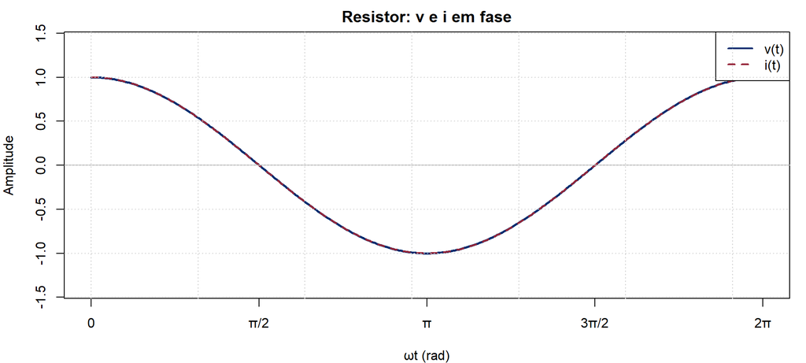

**Características do resistor em CA:**

- Tensão e corrente **em fase** ($\phi_V = \phi_I$)
- Impedância **puramente real**: $\mathbf{Z}_R = R\angle 0°$
- Dissipa energia (potência média $\neq 0$)

## Indutor em CA

**No domínio do tempo:**

$$v(t) = L\frac{di(t)}{dt}$$

Se $i(t) = I_m\cos(\omega t + \theta)$, então:

$$v(t) = -\omega L I_m\sin(\omega t+\theta) = \omega L I_m\cos\!\left(\omega t+\theta+90°\right)$$

**No domínio fasorial** (usando $\frac{d}{dt} \to j\omega$):

$$\mathbf{V} = j\omega L\,\mathbf{I} \implies \mathbf{Z}_L = j\omega L = j X_L$$

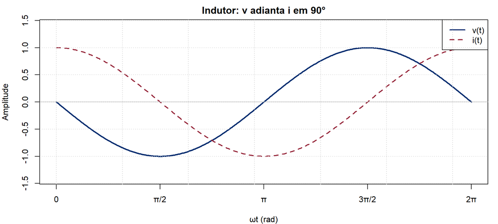

**Características do indutor em CA:**

- Tensão **adianta** a corrente em $90°$ (“ELI”)
- **Reatância indutiva:** $X_L = \omega L$ $[\Omega]$ — aumenta com a frequência
- Não dissipa energia (potência média $= 0$)

## Capacitor em CA

**No domínio do tempo:**

$$i(t) = C\frac{dv(t)}{dt}$$

Se $v(t) = V_m\cos(\omega t + \phi)$, então:

$$i(t) = -\omega C V_m\sin(\omega t+\phi) = \omega C V_m\cos\!\left(\omega t+\phi+90°\right)$$

**No domínio fasorial:**

$$\mathbf{I} = j\omega C\,\mathbf{V} \implies \mathbf{Z}_C = \frac{1}{j\omega C} = \frac{-j}{\omega C} = -jX_C$$

[figure not shown]

**Características do capacitor em CA:**

- Corrente **adianta** a tensão em $90°$ (“ICE”)
- **Reatância capacitiva:** $X_C = \frac{1}{\omega C}$ $[\Omega]$ — diminui com a frequência
- Não dissipa energia (potência média $= 0$)

## Reatância: Resistência a Variações

A **reatância** $X$ mede a oposição ao fluxo de corrente CA devida ao armazenamento de energia:

| Elemento | Reatância | Impedância | Comportamento com $\omega$ |
| --- | --- | --- | --- |
| Resistor | — | $R$ | Independente |
| Indutor | $X_L = \omega L$ | $jX_L$ | Cresce com $\omega$ |
| Capacitor | $X_C = \dfrac{1}{\omega C}$ | $-jX_C$ | Decresce com $\omega$ |

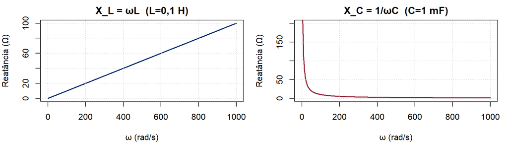

## O Mnemônico ELI the ICEman

**Como memorizar a defasagem**

**ELI**: Em um indutor (**L**), a tensão (**E**) adianta a corrente (**I**)

**ICE**: Em um capacitor (**C**), a corrente (**I**) adianta a tensão (**E**)

**Indutor — ELI:**

$$\mathbf{Z}_L = j\omega L = \omega L\angle 90°$$

$$\mathbf{V}_L = j\omega L\,\mathbf{I} \implies \phi_V = \phi_I + 90°$$

A tensão está $90°$ **à frente** da corrente.

**Capacitor — ICE:**

$$\mathbf{Z}_C = \frac{1}{j\omega C} = \frac{1}{\omega C}\angle{-90°}$$

$$\mathbf{V}_C = \frac{\mathbf{I}}{j\omega C} \implies \phi_V = \phi_I - 90°$$

A tensão está $90°$ **atrás** da corrente.

## Tabela Resumo: R, L e C em CA

|  | Resistor | Indutor | Capacitor |
| --- | --- | --- | --- |
| **Relação v-i (tempo)** | $v = Ri$ | $v = L\dfrac{di}{dt}$ | $i = C\dfrac{dv}{dt}$ |
| **Impedância** | $\mathbf{Z} = R$ | $\mathbf{Z} = j\omega L$ | $\mathbf{Z} = \dfrac{1}{j\omega C}$ |
| **Módulo** | $R$ | $\omega L$ | $\dfrac{1}{\omega C}$ |
| **Ângulo** | $0°$ | $+90°$ | $-90°$ |
| **Defasagem v-i** | Em fase | $v$ adianta $i$ 90° | $i$ adianta $v$ 90° |
| **Potência média** | $\dfrac{V_m I_m}{2}$ | $0$ | $0$ |

## Admitância

A **admitância** $\mathbf{Y}$ é o inverso da impedância:

$$\mathbf{Y} = \frac{1}{\mathbf{Z}} = G + jB \qquad [\text{S} = \Omega^{-1}]$$

- $G$ — condutância (parte real)
- $B$ — susceptância (parte imaginária)

| Elemento | Impedância | Admitância |
| --- | --- | --- |
| Resistor | $R$ | $G = \dfrac{1}{R}$ |
| Indutor | $j\omega L$ | $\dfrac{1}{j\omega L} = -\dfrac{j}{\omega L}$ |
| Capacitor | $\dfrac{1}{j\omega C}$ | $j\omega C$ |

**Tip**

A admitância é conveniente para **elementos em paralelo**: $\mathbf{Y}_{total} = \mathbf{Y}_1 + \mathbf{Y}_2 + \cdots$

## Impedâncias em Série e Paralelo

As mesmas regras do CC se aplicam no domínio fasorial:

**Série:**

$$\mathbf{Z}_{eq} = \mathbf{Z}_1 + \mathbf{Z}_2 + \cdots + \mathbf{Z}_N$$

Divisor de tensão:

$$\mathbf{V}_k = \frac{\mathbf{Z}_k}{\mathbf{Z}_{eq}}\,\mathbf{V}_{total}$$

**Paralelo:**

$$\frac{1}{\mathbf{Z}_{eq}} = \frac{1}{\mathbf{Z}_1} + \frac{1}{\mathbf{Z}_2} + \cdots$$

Divisor de corrente (dois elementos):

$$\mathbf{I}_1 = \frac{\mathbf{Z}_2}{\mathbf{Z}_1 + \mathbf{Z}_2}\,\mathbf{I}_{total}$$

**Atenção**

Impedâncias são números **complexos** — as operações devem ser feitas com álgebra complexa, não com módulos diretamente.

## Exemplo 1: Indutor em CA

**Problema:** Um indutor de $L = 10\text{ mH}$ tem tensão $v(t) = 50\cos(2000t + 30°)$ V. Encontre a corrente $i(t)$.

**Solução:**

1. Fasor da tensão: $\mathbf{V} = 50\angle 30°$ V
2. Impedância do indutor: $\mathbf{Z}_L = j\omega L = j(2000)(0{,}01) = j20\ \Omega = 20\angle 90°\ \Omega$
3. Corrente fasorial:
   $$\mathbf{I} = \frac{\mathbf{V}}{\mathbf{Z}_L} = \frac{50\angle 30°}{20\angle 90°} = 2{,}5\angle(30°-90°) = 2{,}5\angle{-60°}\ \text{A}$$
4. Volta ao domínio do tempo:
   $$\boxed{i(t) = 2{,}5\cos(2000t - 60°)\ \text{A}}$$

> A corrente **atrasa** a tensão em $90°$, como esperado para um indutor.

## Exemplo 2: Capacitor em CA

**Problema:** Um capacitor de $C = 100\,\mu\text{F}$ tem corrente $i(t) = 8\cos(200t + 15°)$ mA. Encontre a tensão $v(t)$.

**Solução:**

1. Fasor da corrente: $\mathbf{I} = 8\angle 15°$ mA
2. Impedância do capacitor:
   $$\mathbf{Z}_C = \frac{1}{j\omega C} = \frac{1}{j(200)(100\times10^{-6})} = \frac{1}{j0{,}02} = -j50\ \Omega = 50\angle{-90°}\ \Omega$$
3. Tensão fasorial:
   $$\mathbf{V} = \mathbf{Z}_C\,\mathbf{I} = (50\angle{-90°})(8\times10^{-3}\angle 15°) = 0{,}4\angle{-75°}\ \text{V}$$
4. Volta ao domínio do tempo:
   $$\boxed{v(t) = 0{,}4\cos(200t - 75°)\ \text{V}}$$

> A tensão **atrasa** a corrente em $90°$, como esperado para um capacitor.

## Exemplo 3: Circuito RL Série

**Problema:** Circuito com $R = 3\,\Omega$ e $L = 4\text{ mH}$ em série, alimentado por $v_s(t) = 10\cos(500t)$ V. Encontre a corrente e as tensões em cada elemento.

**Solução:**

$$\mathbf{Z}_{RL} = R + j\omega L = 3 + j(500)(0{,}004) = 3 + j2\ \Omega$$

$$|\mathbf{Z}| = \sqrt{3^2+2^2} = \sqrt{13} \approx 3{,}61\ \Omega, \qquad \phi = \arctan\!\left(\frac{2}{3}\right) \approx 33{,}7°$$

$$\mathbf{I} = \frac{\mathbf{V}_s}{\mathbf{Z}} = \frac{10\angle 0°}{3{,}61\angle 33{,}7°} = 2{,}77\angle{-33{,}7°}\ \text{A}$$

$$\mathbf{V}_R = R\,\mathbf{I} = 3(2{,}77\angle{-33{,}7°}) = 8{,}31\angle{-33{,}7°}\ \text{V}$$

$$\mathbf{V}_L = j\omega L\,\mathbf{I} = (2\angle 90°)(2{,}77\angle{-33{,}7°}) = 5{,}54\angle 56{,}3°\ \text{V}$$

$$\boxed{i(t) = 2{,}77\cos(500t-33{,}7°)\ \text{A}}$$